# ECOINFORMÁTICA: Retos - Sesión 3

Beatriz Pérez Cazorla

En este documento de R-markdown se realizarán los retos de programación en R-project version 3.0.2. propuestos para la sesión 3. Los resultados que se muestran en R-markdown para el reto_3_p1.R, .p2.R., y .p3.R son nulos porque es el usuario quien ha de introducir los valores para ejecutar las operaciones.

**Reto_3_p1.R: Algoritmo que multiplique 5 números introducidos por el usuario**

```r
multiplica<-1
a<-scan(n=5) # la función scan nos permite que sea el usuario quien introduzca los números
for(valor in a){
  multiplica<-multiplica*valor
} # creamos un bucle que multiplique los números introducidos
print(multiplica) # mostramos el resultado
```

```
## [1] 1
```

**Reto_3_p2.R: Algoritmo que dado un umbral por el usuario, dados 10 números por el usuario, cuente cuántos de esos números supera el umbral indicado**

```r
suma<-0  # reincializamos a 0
a<-scan(n=10) # scan permite que el usuario introduzca la cantidad de números que le indicamos (en este caso 10)
umbral<-10 # establecemos el umbral
for(valor in a){
  if(valor>umbral){
    suma<-suma+1}} # creamos un bucle que nos de el número de valores introducidos que superan dicho umbral

print(suma)
```

```
## [1] 0
```

**Reto_3_p3.R: Algoritmo que haga la media de 10 temperaturas indicadas por el usuario**

```r
a<-scan(n=10) # el usuario ha de introducir las 10 temperaturas
mean(a) # la funcion mean() nos hace la media
```

```
## [1] NaN
```

**Reto_3_p4.R. Muestra la evolución del NDVI medio para las horas del día.** *A continuacion se muestran dos formas de realizarlo. Cada archivo tiene tres imagenes por cada hora, en total 4 horas, 12 fotos:*

```r
### Evolución del NDVI a lo largo de las horas de un día con bucle ###

# install.packages("raster",dep=T) # instalamos los paquetes necesarios
library(raster) # cargamos el paquete
getwd() # vemos el directorio de trabajo en el que estamos
```

```
## [1] "/home/bcazorla/ecoinformatica_2014_2015/sesion_3/retos"
```

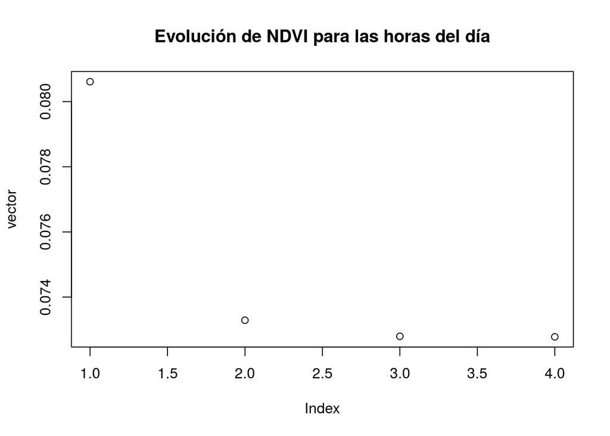

```r
setwd("~/ecoinformatica_2014_2015/sesion_3/retos/Reto_3_p1/ndvi") # establecemos nuestro directorio de trabajo
hora<-c("12","13","14","15") # creamos un vector con las horas de las imágenes
vector<-c() # creamos un vector vacío que posteriormente rellenaremos con los resultados
for (x in hora) { # creamos un bucle que nos ejecute la siguiente orden para cada hora
  imagenes<- list.files(path="/home/bcazorla/ecoinformatica_2014_2015/sesion_3/retos/Reto_3_p1/ndvi", full.names = TRUE,
                        pattern=paste("_", x, "..\\.jpg\\.asc$", sep="")) # creamos una lista con las imágenes de ndvi para cada hora
  a<-stack(imagenes) # las agrupamos
  b<-mean(a) # hacemos la media de todas las imágenes
  f<-mean(b[]) # hacemos la media de los resultados anteriores, para obtener una sola media por hora
  vector<-rbind(vector,f) # guardamos los resultados en el vector vacío
}
plot(vector,  main="Evolución de NDVI para las horas del día") mostramos los resultados con un plot
```

Aquí se muestra otra forma de realizarlo. La más apropiada sería la primera, puesto que un bucle nos facilita el procesamiento de numerosos datos. Hemos sido capaces de hacer el proceso que describimos a continuación debido a que para cada hora no teníamos una gran cantidad de datos, en el caso de que los tuvieramos, no sería útil realizarlo por esta vía.

```r
###### Evolución del NDVI a lo largo de las horas de un día sin bucle ######

# Vemos donde está el directorio de trabajo
#getwd()

# Establecemos el directorio donde queremos
setwd("/home/bcazorla/ecoinformatica_2014_2015/sesion_3/retos/Reto_3_p1/ndvi")

# Instalar y llamar paquetes necesarios
#install.packages("raster", dep=T) # si lo tenemos instalado con anterioridad este paso no es necesario
library(raster) # si lo hemos cargado anteriormente, tampoco necesitamos volver a cargar el paquete.

library(rgdal)
```

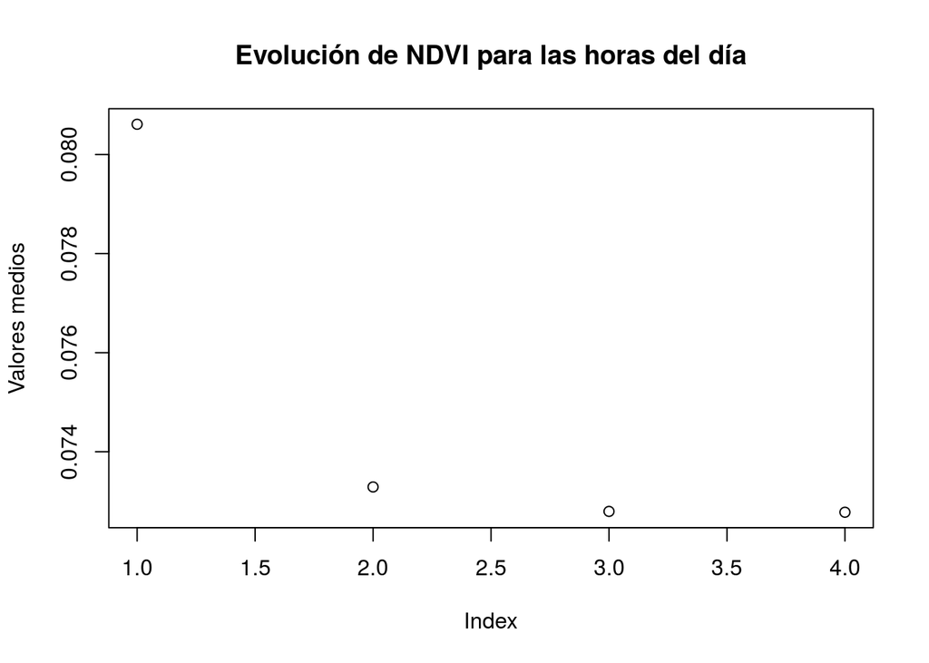

```r
# Cargar los archivos de las variables (son una lista de archivos)
listndvi<- list.files("/home/bcazorla/ecoinformatica_2014_2015/sesion_3/retos/Reto_3_p1/ndvi", pattern='ndvi', full.names=TRUE)

# Concatenamos la lista en una sola variable(ndvi)
#?stack # la "?nombre_funcion" nos permite obtener ayuda sobre la función
ndvi<-stack(listndvi)

# Hacemos la media de cada hora, hemos de tener en cuenta los tres valores de cada hora
mean_12h<-mean(ndvi$ndvi_2014_220_1200.jpg,ndvi$ndvi_2014_220_1220.jpg, ndvi$ndvi_2014_220_1240.jpg)
mean_13h<-mean(ndvi$ndvi_2014_220_1300.jpg, ndvi$ndvi_2014_220_1320.jpg, ndvi$ndvi_2014_220_1340.jpg)
mean_14h<-mean(ndvi$ndvi_2014_220_1400.jpg, ndvi$ndvi_2014_220_1420.jpg, ndvi$ndvi_2014_220_1440.jpg)
mean_15h<-mean(ndvi$ndvi_2014_220_1500.jpg, ndvi$ndvi_2014_220_1520.jpg, ndvi$ndvi_2014_220_1540.jpg )

# Acumulamos la media de las horas, para saber la evolución media de cada hora de nuestras imágenes

# Al intentar hacerlo, me daba el siguiente error: Error no method for coercing this S4 class to a vector, por lo tanto, pasamos nuestras variables a vectores
vectormean_12h<-as.vector(mean_12h)
vectormean_13h<-as.vector(mean_13h)
vectormean_14h<-as.vector(mean_14h)
vectormean_15h<-as.vector(mean_15h)

# Ahora sí, acumulamos los valores medios de cada hora
total_mean<-rbind(vectormean_12h,vectormean_13h,vectormean_14h,vectormean_15h)

# Con los cálculos anteriores, hemos obtenido varios valores medios, los de cada imagen para cada hora. Pero necesitamos un sólo valor medio de cada hora por imagen, por lo tanto, le hacemos la media al contenido de los resultados anteriores
a<-mean(vectormean_12h[])
b<-mean(vectormean_13h[])
c<-mean(vectormean_14h[])
d<-mean(vectormean_15h[])

## Creamos un vector donde irán todas nuestras medias
total_mean<-c(a,b,c,d)

# Dibujamos los resultados
plot(total_mean, main="Evolución de NDVI para las horas del día", ylab="Valores medios")
```

Añadido: eliminar valores del raster que estén por encima de un umbral

```r
#hora<-c("12","13","14","15")
#umbral<-0.15
#vector<-c()
#for (x in hora) {
#  imagenes<- list.files(path="/home/bcazorla/ecoinformatica_2014_2015/sesion_3/retos/Reto_3_p1/ndvi", full.names = TRUE,
#                        pattern=paste("_", x, "..\\.jpg\\.asc$", sep=""))
#  a<-stack(imagenes)
#           b<-mean(a)
#           f<-mean(b[])
#           vector<-rbind(vector,f)
#  }

# vector_umbral<- if(vector<umbral){ * vector
#}
```

No lo he podido conseguir…